# Project 3: Bioinformatics of Gene Expression

Merrimack College DSE6630: Healthcare & Life Sciences Analytics

Elizabeth Greenan

3 July 2026

# 1 Background to the Project

## 1.1 Overview

At the end of Demo_3, you hopefully concluded that the SVM was performing better than the Random Forest algorithm, at least OOB. But the biggest problem we saw with both algorithms is sign of **overfitting**: when the testing error was higher than the training error (i.e., testing accuracy < training accuracy). Well, thankfully, we can address this with **cross-validation** and **tuning the hyperparameters**.

## 1.2 Overfitting

When we optimize the model for the training data, our model will score very well on the training set. We expect this to be true (if it doesn’t, then training failed!). However, there may be times when the model in turn is not **generalizable**, meaning that it does not perform nearly as well on the test data set. When a model performs highly on the training set but poorly on the test set, this is known as **overfitting**. We have created a model that knows the training set very well but cannot be applied to new problems. Many textbooks use this analogy of overfitting, and I think it works very well: > We all knew a student in school who could memorize information, like answers to a quiz, but failed to apply those concepts in the real-world. That student’s mind was overfitted!

Therefore, an overfitted model can look great on the training set but will be useless on other data because it is not generalizable. As mentioned above, we do have two keys ways of helping with this, though.

## 1.3 Cross-validation

You may have encountered $k$-fold CV before, in which case, excellent - you will already have a sense for what we are doing and why. But, if not, let’s have a gentle introduction to cross-validation. You are all already familiar with the idea that we split our dataset into a training and a testing set. $k$-fold CV further splits the training set into a $k$ number of subsets also called **“folds”**. The model is fit iteratively $k$ times where each each time the training set contains $k-1$ folds and the model is evaluated on the $k^{th}$ fold. The most commonly used folds on personal computers are $k = 5$ and $k = 10$ for 5% hold-out and 10% hold-out at each iteration, respectively, but you can fit up to $n-1$ folds if you have the computational resources, where $n$ is the number of observations!

## 1.4 Hyperparameter Tuning

What is a **hyperparameter**? Model parameters are those that are learned during training, e.g., the slope and intercept in a linear regression. Hyperparameters are external and not learned, and therefore must be set (or generated by default) by the data scientist before training. In the case of a random forest, hyperparameters include the the number of features considered by each tree when splitting a node for random forest or the kernel in SVM. Since the best hyperparameters are not something we can choose *a priori*, this is why we **tune the hyperparameters** as we train the model. This is done using trial-and-error, although there are some guidelines can often keep in mind to help ensure that we our models are on a good learning path.

As we (or the package we are using) performs the tuning, we are performing many iterations of the entire cross-validation process, whether that is $k$-fold or another CV method. We then compare all models, select the best one based on a performance metric (typically RMSE for regression or accuracy for classification), and train it on the full training set. Once we have our best model, we will then evaluate it on the testing set. Thus, even though you may not necessarily see all of the iterations involved, be aware of how extensive this process actually is!

## 1.5 Objectives

We will spend our final class session this term briefly discussing overfitting, cross-validation, and hyperparameter tuning in the context of project planning. From here down, I give you a demo how to tune the Random Forest we fit last week to the VST expression data for the bumblebee chill-coma experiment. **Your objective** will be to apply all the same methods to the SVM and compare and contrast your findings. Specifically, we will compare and contrast **nested cross-validation** versus **$k$-fold cross-validation** to see how well, if at all, we are able to overcome the **P >> n** problem we discussed in Demo_3.

## 1.5.1 Your Tasks:

### 1. Answer questions scattered throughout the Random Forest CV and Tuning Sections to ensure your understanding (you may copy these answers, without code, to your project document.)

### 2. Your own novel analysis! Choose from:

- [Easier] Perform $k$-fold & nested CV, as well as hyperparameter tuning, on SVM a different VST (from the 30-minute experiment only)
- [Harder] Ready to do go farther? Try performing $k$-fold & nested CV, as well as hyperparameter tuning, on SVM.

## 1.5.2 Housekeeping

### 1.5.2.1 Loading Data

To make your life easier, we will load some pre-prepared datasets from our work in Demo_3. That way, we don’t need to spend the computational time running our DESeq and previous machine learning models all over again!

```r
# Updated file path to match my local
load("../../Module_Demos/Demo_3/vst_all_timepoints.Rdata")  ## These are the all time-points
                                            ## used for Demo_3
load("./data/DESeqResults.Rdata")                ## Load the results of the all time
                                            ## points DESeq analysis (so you
                                            ## don't have to run it again)
load("./data/OOB_RF_Importance.Rdata")   ## Load the OOB RF importance from
                                            ## Demo_3 for comparison
load("./data/OOB_SVM_Importance.Rdata")  ## Load the OOB SVM importance from
                                            ## Demo_3 for comparison
```

### 1.5.2.2 Functions

Similarly, I have written some functions to make your life easier. Although I do not require you to take the time to annotate them, it can be great practice in code reading to take a stab at trying to understand exactly *how* these functions do what they do.

#### 1. `doSplits()`

This function quickly and easily performs data partitioning & pre-processing of the datasets, depending on algorithm chosen. This function could also facilitate automated testing of filtering cutoffs or split-ratios by algorithm, if desired.

#### 2. `findOverlappingGenes()`

Function that compares the `DESeq` results at a given log-fold change (LFC) with the list of important genes from an ML classifier. This could again be iterated over to automate collation of results for more automated comparisons.

#### 3. `compareConfusion()`

This function compares the results of confusion matrices by printing them in a table side-by-side. You could also use this to graph your results, if desired.

# 2 Tuning the Random Forest Model

One of the reasons that random forest is generally considered to work so well OOB is that it picks up a portion of the predictors for training. At each step, it randomizes the variable selection during each tree split. Thus, it is doing its own form of cross-validation internally as part of the algorithm. This is also even the OOB is considered to be less prone to overfitting as compared to other machine learning algorithms.

That said, we can explicitly apply an external cross-validation too - **because even models that are more robust to overfitting are STILL capable of being overfitted.**

More importantly, though, there are certain **hyperparameters** of random forests that will assist with overfitting much better than cross-validation given the internal split-variable randomization of the algorithm.

**Note**: One of the other advantages to RF that you may come across is that it is *more* robust to multicollinearity. Why? Well, since the algorithm is randomly selecting a certain number of samples via bootstrapping to train on and another random sample of features at each split, then a more diverse set of trees is produced. It tends to lessen correlation among the trees and would have the potential to ‘break up’ multicollinearity in the process. However, being “more” robust is not the same thing as being perfectly robust! It is worth thinking this through if, for example, we expect similar **kinds** of genes to be expressed in response to chill coma.

## 2.1 Random Forest Hyperparameters

### 2.1.1 Number of features at any given split.

Each time a split is to be performed, the search for the split variable is limited to a random subset of the $p$ features. In R’s packages `randomForest` and `ranger`, this hyperparameter is called $m_{try}$ and is arguably one of the single most important hyperparameters to tune. By default, for regression RF, $m_{try} = \frac{p}{3}$ and for classification RF, $m_{try} = \sqrt{p}$.

But let’s think about that: our OOB random forest, by default, would have run an $m_{try} = \sqrt{12927}$ or $approx$ 113.6969657. Thus, $m_{try}$ is often one of the first hyperparameters you should consider tuning for random forest.

### 2.1.2 Number of trees in the forest.

**How many trees should you have in your forest?** Although this isn’t technically a hyperparameter, if you do not have enough trees in your forest, you will not be able for your model to **converge**, i.e., stabilize the error rate. Note that one of the cross-validation packages we will use, `train()` from the `caret` package does not allow us to tune **num.trees**. I will be showing you a work-around for that.

Also, note that [Hands-on Machine Learning in R](https://bradleyboehmke.github.io/HOML/random-forest.html) recommends starting with $num.trees = 10 \cdot p$, but the challenge for us is **how massive the computational time would be**. DO NOT ATTEMPT THIS! By these recommendations, you would set an $num.trees =$ 1.2927^{5}, which would only crash your computer!

**Instead, I am going to recommend an** $num.trees \leq 2000$ **unless you have wayyyy more computing power than I do at the moment ;).**

### 2.1.3 Complexity of each tree, aka, node split.

Whereas the number of features at any given split ($m_{try}$) allows us to control the learning of the algorithm, the node split allows us to control the complexity of the individual trees in the forest. The default values are typically 1 and 5 for classification and regression, respectively, and while the default can work well on many datasets, noisier datasets or those that require higher values of $m_{try}$ may perform better with **increased** values of node size. Increasing values of node size **decreases** complexity and thereby tree depth. Further, larger node sizes can often speed up computation without large sacrifices to error rates.

### 2.1.4 Splitting rule to use during tree construction.

The main rules we will be using are the **gini** rule and the **extratrees** rule. We will practice tuning these rules to see what effect, if any, they can have on forest construction and overall accuracy.

#### **Question 1**: Look up these rules and try to explain what they are doing for yourself.

Source: “Gini Impurity and Entropy in Decision Tree.” Geeks for Geeks, 8 Nov. 2025, www.geeksforgeeks.org/machine-learning/gini-impurity-and-entropy-in-decision-tree-ml/.

Additional source: Referenced Module 6 PPT. from DSE6111

> The Gini rule is also known as Gini impurity. This metric selects the split that reduces impurity the most. When there is a gini impurity of 0, that means that the node is pure and that everything is in the same class. It is used when determining how well the data should be split into branches in a random forest model. According to Geeks for Geeks, “Gini Impurity checks how often a randomly selected sample would be mislabeled if assigned by class probability” (Gini Impurity and Entropy in Decision Tree). This metric is used in algorithms such as CART (Classification and Regression Trees) to determine splits.

Source: “Extratreesclassifier — Scikit-Learn 1.9.0 Documentation.” Scikit Learn, scikit-learn.org/stable/modules/generated/sklearn.ensemble.ExtraTreesClassifier.html. Accessed 27 June 2026.

Source: “How Extra Trees Classification and Regression Algorithm Works.” ESRI, doc.esri.com/en/arcgis-pro/latest/tool-reference/geoai/how-extra-tree-classification-and-regression-works.html. Accessed 27 June 2026.

> The extratrees (also known as extremely randomized trees) rule is based on randomized decision trees. According to ESRI, it is similar to the random forest algorithm, since it creates multiple decision trees. ESRI also noted that it is often faster than random forest. However, each split is selected randomly. This is different from other models, where the optimal splits are calculated. A benefit of extratrees is that it helps reduce overfitting in the model.

### Sampling scheme.

This would allow us to alter whether we are sampling features with or without replacement at each node split. We will not be tuning this at this time.

## 2.2 Pre-processing and feature selection

Two important elements of the data science life cycle that we did not have a chance to get into yet last week in Assignment 1 was **pre-processing** (which includes transformations, encoding, splitting, and normalizing) and **feature selection** (which includes reduction of the number of features or dimensionality of the dataset). We will spend more time on both of these topics throughout the course, but for this project it is largely hidden in the function that I wrote for us above, `doSplits()`.

#### **Question 2**: Take a moment to go look at the function and the documentation I have written. Also try playing with the parameters a bit - how many more or fewer genes do you get when you lower or raise the `filterCutoff`, respectively?

```r
splits <- doSplits(vst = vsData,
                   algorithm = "rf",
                   splitRatio = 0.8,
                   filterCutoff = 10) # Tested 1, 2, and 10
```

```
## [1] "After filtering, number of genes in the dataset are: 765"
```

```r
train <- splits[[1]]
test <- splits[[2]]
```

> With the original filterCutoff value of 5, there were 7,676 genes in the dataset after filtering. Keeping everything else the same, I then decreased the filterCutoff, testing it with both values 1 and 2. This caused the number of genes in the dataset to increase to 12,927 in both cases. This showed that a lower filterCutoff filters fewer genes out. It was interesting that the number of genes did not change between filterCutoff values 1 and 2. This showed that in this case, the slight change in the filterCutoff value did not impact the number of genes being filtered out.

> Next, I increased the filterCutoff to 10. There were 765 genes in the dataset after filtering. This showed that a higher filterCutoff value filters more genes out.

Notice in the comments that I am only doing feature selection on the training data set. Why? Current research strongly suggests that filtering on the entire dataset has the potential to generate bias, not surprisingly, which in turn can create **data leakage**. The advice of Vabalas et al. (2019) is to only do our feature selection **only on the training model**.

#### **Question 3a**: Do some research on **data leakage** and try to explain what that means in this context. Why do we care about data leakage?

> Data leakage happens when data that should not be used during model training is used. An example of this is if the test data is used during training. Ensuring data leakage does not happen is important for various reasons. When there is data leakage, the model will initially look strong and will likely have high performing metrics such as accuracy, recall, and precision. However, once the model is run on unseen data, it will not perform nearly as well.

> In the context of Project 3, this is why we only performed feature selection on the training set. When we move onto cross-validation and additional tuning in later sections, that will be performed on the training set. This ensures that the model results are not inflated during training.

Now, we will set `filterCutoff = 5` and partition data for random forest tuning.

```r
splits <- doSplits(vst = vsData,
                   algorithm = "rf",
                   splitRatio = 0.8,
                   filterCutoff = 5)
```

```
## [1] "After filtering, number of genes in the dataset are: 7676"
```

```r
train <- splits[[1]]
test <- splits[[2]]
```

#### **Question 3b**: Using the annotation I have provided in the function `doSplits()`, explain the parameters chosen and try to explain *why* you think they were chosen, based on what we did in Demo_3. In particular, make sure to explain WHY a filterCutoff of 5 was chosen. (**Hint**: In Demo_3, did we do anything to adjust for genes with low variance in expression?)

> The vst = vsData parameter represents the data used in the split. Algorithm = “rf” means that the algorithm used is a random forest model. The split ratio (splitRatio) = 0.8 represents a training and testing split of 80% and 20% respectively. This is further annotated in the train and test code above.

> In Demo 3, we identified genes with low variance in expression, but did not filter these genes out. In this case, low variance in expression was represented by the chill coma the bumblebees were in. Filtering these genes out would have taken away valuable data from when the bees were in their coma, negatively impacting the benchmarking study. In Project 3, based on the code above, we do want to filter out some of these genes.

> In this project, after filtering with a filterCutoff = 5, there are 7,676 genes in the dataset. I think a value of 5 was chosen because it removes a signficiant number of low expression genes from the dataset, without removing too many. Based on my experimentation of the filterCutoff values in Question 2, I saw that if the filterCutoff value was too low, not enough genes would be filtered out. If the filterCutoff value was too high, too many genes were filtered out. Choosing a value of 5 allows for a sufficient number of genes to remain, without keeping too many, which could create too much noise.

## 2.3 Apply $k$-fold Cross-Validation (CV) to Random Forest

### 2.3.1. Leverage the `trainControl()` and `train()` functions from the `caret` package.

Recall that when were doing OOB random forest in Demo_3, we didn’t use `trainControl()`. That will be a deviation from what we do this time.

However let’s first fit the same RF we fit last week for comparison:

```r
rfOOB <- randomForest::randomForest(
  Treatment ~ .,
  data = train)

pred.test.rf <- predict(rfOOB, test, type = "response")
confMat <- confusionMatrix(pred.test.rf, test$Treatment)
```

### 2.3.2. Employ a $k$-fold CV where $k = 10$.

Set the control for $k = 10$ and then run the RF:

```r
# Set the CV arguments
kFoldCtrl <- trainControl(method = "cv",    ## for k-fold CV
                          number = 10)      ## k
```

And fit the Random Forest model:

```r
rfCV <- train(Treatment ~.,
               data = train,
               method = "ranger",
               trControl = kFoldCtrl)    ## added in the 10-fold CV
```

#### **Question 4**: Explain, in your own words, what a 10-fold CV does here. Is it vital to perform with a random forest? Why or why not?

> A 10-fold cross-validation (CV) splits the training data into 10 different folds and has a 10% hold-out at each iteration. This allows the model to be trained 10 times. 1 fold will be used for testing, while the remaining 9 folds will be used for training. This method often provides better model performance metrics. While not vital to perform with a random forest, it is often used to enhance the model and better understand the results. It can be beneficial to use, as it allows us to evaluate the stability of the model and also provides insight on how the model will perform on unseen test data.

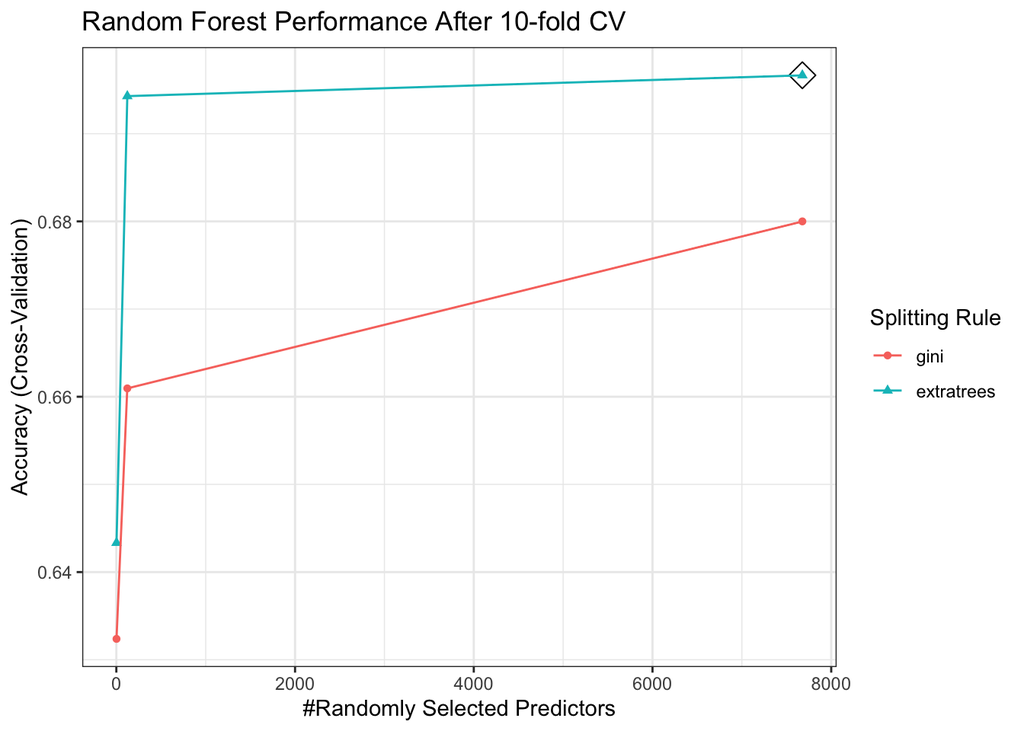

Figure 1. Visualize the 10-fold CV Performance

You’ll notice that by default with the 10-fold CV is that **it is doing automated hyperparameter tuning too!** Also, note the x-axis here. It is actually the $m_{try}$ hyperparameter, the number of randomly selected predictors $P$ at each split. This allows us to **visualize the effect of** $m_{try}$ **on accuracy.**